# EDA_project

RanjanK

January 9, 2018

# EDA_Project by Ranjan Kumar

The dataset wineQualityReds contains 1,599 red wines with 11 variables on the chemical properties of the wine. At least 3 wine experts rated the quality of each wine, providing a rating between 0 (very bad) and 10 (very excellent). Our goal here is to identify the chemical properties that influence the quality of red wines.

# Univariate Plots Section

Let’s have a look at the basic statistics and structure of our dataset.

```
## 'data.frame':    1599 obs. of  13 variables:
##  $ X                   : int  1 2 3 4 5 6 7 8 9 10 ...
##  $ fixed.acidity       : num  7.4 7.8 7.8 11.2 7.4 7.4 7.9 7.3 7.8 7.5 ...
##  $ volatile.acidity    : num  0.7 0.88 0.76 0.28 0.7 0.66 0.6 0.65 0.58 0.5 ...
##  $ citric.acid         : num  0 0 0.04 0.56 0 0 0.06 0 0.02 0.36 ...
##  $ residual.sugar      : num  1.9 2.6 2.3 1.9 1.9 1.8 1.6 1.2 2 6.1 ...
##  $ chlorides           : num  0.076 0.098 0.092 0.075 0.076 0.075 0.069 0.065 0.073 0.071 ...
##  $ free.sulfur.dioxide : num  11 25 15 17 11 13 15 15 9 17 ...
##  $ total.sulfur.dioxide: num  34 67 54 60 34 40 59 21 18 102 ...
##  $ density             : num  0.998 0.997 0.997 0.998 0.998 ...
##  $ pH                  : num  3.51 3.2 3.26 3.16 3.51 3.51 3.3 3.39 3.36 3.35 ...
##  $ sulphates           : num  0.56 0.68 0.65 0.58 0.56 0.56 0.46 0.47 0.57 0.8 ...
##  $ alcohol             : num  9.4 9.8 9.8 9.8 9.4 9.4 9.4 10 9.5 10.5 ...
##  $ quality             : int  5 5 5 6 5 5 5 7 7 5 ...
```

```
##        X          fixed.acidity   volatile.acidity  citric.acid
##  Min.   :   1.0   Min.   : 4.60   Min.   :0.1200   Min.   :0.000
##  1st Qu.: 400.5   1st Qu.: 7.10   1st Qu.:0.3900   1st Qu.:0.090
##  Median : 800.0   Median : 7.90   Median :0.5200   Median :0.260
##  Mean   : 800.0   Mean   : 8.32   Mean   :0.5278   Mean   :0.271
##  3rd Qu.:1199.5   3rd Qu.: 9.20   3rd Qu.:0.6400   3rd Qu.:0.420
##  Max.   :1599.0   Max.   :15.90   Max.   :1.5800   Max.   :1.000
##  residual.sugar     chlorides       free.sulfur.dioxide
##  Min.   : 0.900   Min.   :0.01200   Min.   : 1.00
##  1st Qu.: 1.900   1st Qu.:0.07000   1st Qu.: 7.00
##  Median : 2.200   Median :0.07900   Median :14.00
##  Mean   : 2.539   Mean   :0.08747   Mean   :15.87
##  3rd Qu.: 2.600   3rd Qu.:0.09000   3rd Qu.:21.00
##  Max.   :15.500   Max.   :0.61100   Max.   :72.00
##  total.sulfur.dioxide    density             pH          sulphates
##  Min.   :  6.00       Min.   :0.9901   Min.   :2.740   Min.   :0.3300
##  1st Qu.: 22.00       1st Qu.:0.9956   1st Qu.:3.210   1st Qu.:0.5500
##  Median : 38.00       Median :0.9968   Median :3.310   Median :0.6200
##  Mean   : 46.47       Mean   :0.9967   Mean   :3.311   Mean   :0.6581
##  3rd Qu.: 62.00       3rd Qu.:0.9978   3rd Qu.:3.400   3rd Qu.:0.7300
##  Max.   :289.00       Max.   :1.0037   Max.   :4.010   Max.   :2.0000
##     alcohol         quality
##  Min.   : 8.40   Min.   :3.000
##  1st Qu.: 9.50   1st Qu.:5.000
##  Median :10.20   Median :6.000
##  Mean   :10.42   Mean   :5.636
##  3rd Qu.:11.10   3rd Qu.:6.000
##  Max.   :14.90   Max.   :8.000
```

Looking at the summary of the variables, we can deduce that sulphates, chlorides, residual.sugar and total.sulfur.dioxide have outliers.

Let’s check, do we have any missing value.

```
## [1] FALSE
```

That is awesome! We don’t have any missing value. Let’s have a closer look at how the quality of wine is distributed.

```
##
##   3   4   5   6   7   8
##  10  53 681 638 199  18
```

```
## [1] 5.636023
```

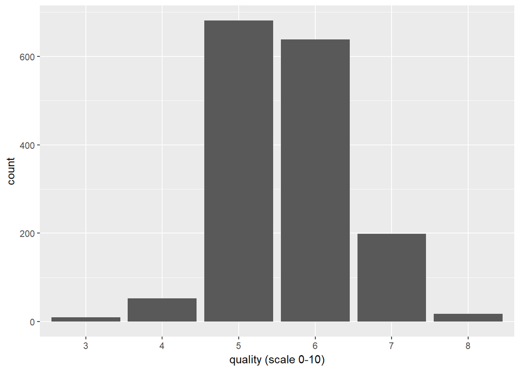

[output not shown]

Lets have a closer look at the data:

```
##
##   3   4   5   6   7   8
##  10  53 681 638 199  18
```

```
## [1] 5.636023
```

Okay! So nearly, 95% of the red wines have a quality rating of 5, 6 or 7. And the average rating of the red wines is around 5.6

Now, let’s have a look at the distribution of the independent variables.

```
## [1] "Distrbution of independent variables"
```

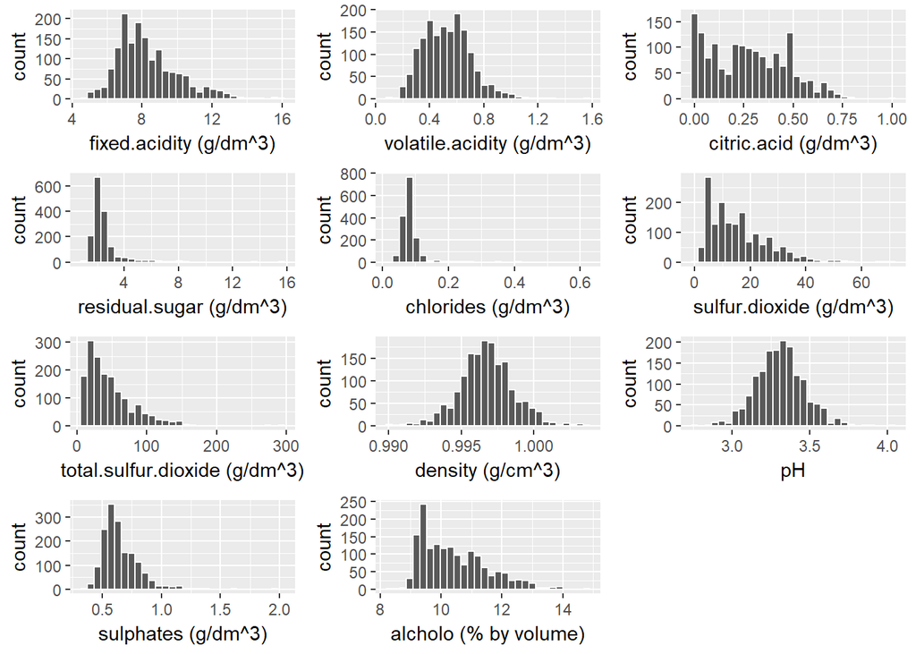

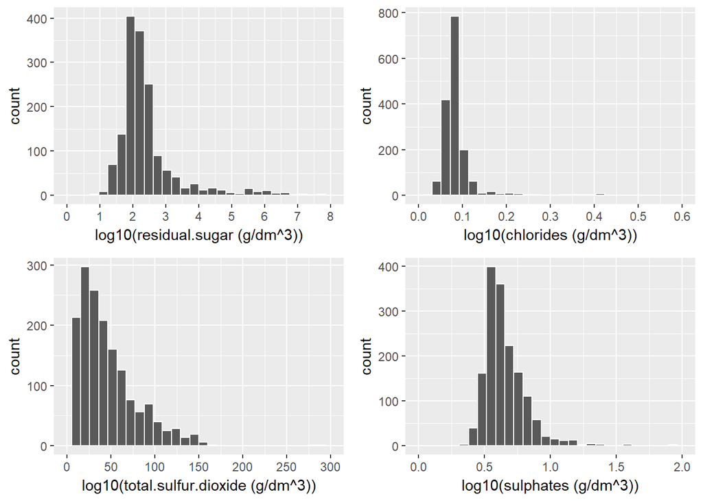

Lets trim the top 2.5% data and observe.

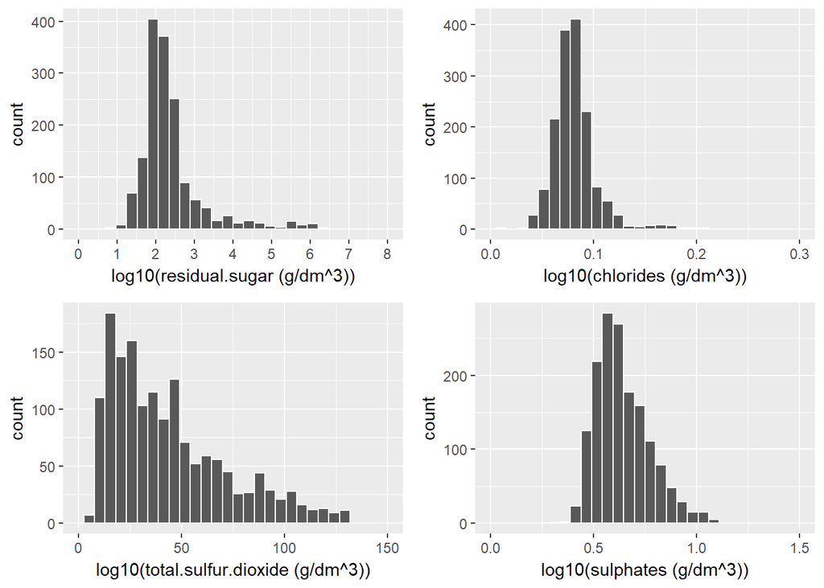

# Univariate Analysis

We can see that all the 11 independent variables are decimals and the dependent variable wine quality is integer.

Looking at the summary of the variables, we can deduce that sulphates, chlorides, residual.sugar and total.sulfur.dioxide have outliers.

It is interesting to know that 95% of the data have rating 5, 6 or 7. We don’t have any missing value and that is great.

I did not create any new variable, because, I felt that all the variables represent a chemical properties/parameter that are difficult to interpret and most likely might not be amenable to any combination. However, I did create a few categorical variables that didn’t prove to be of much use later.

# Bivariate Plots Section

Before, we dive deep, let’s have a casual look at the relationship between the each pair of the variables.

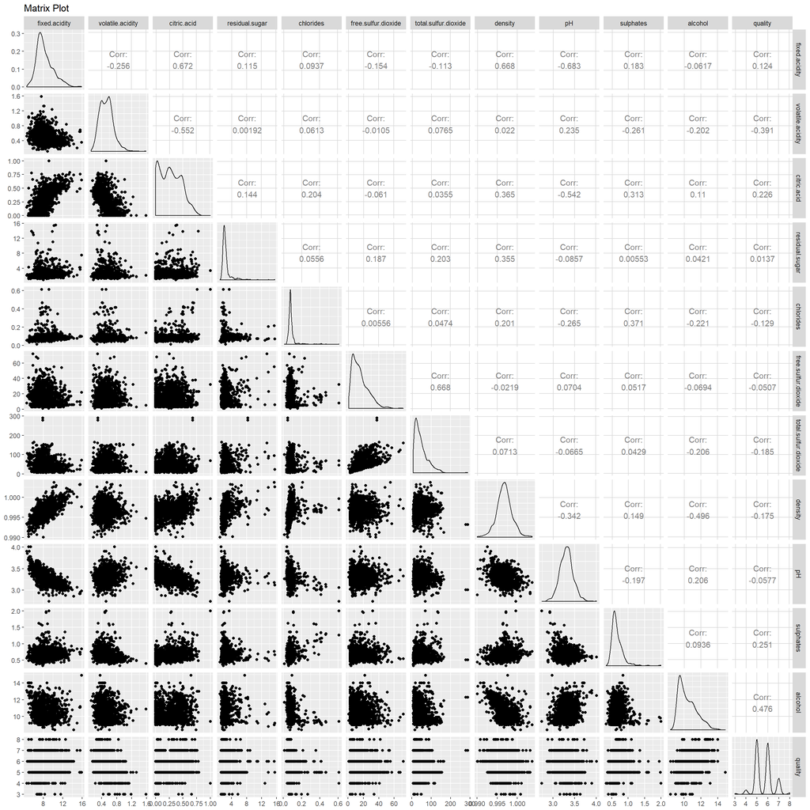

It appears that if we had quality as a factor rather than numeric it would give a better insight in the data.

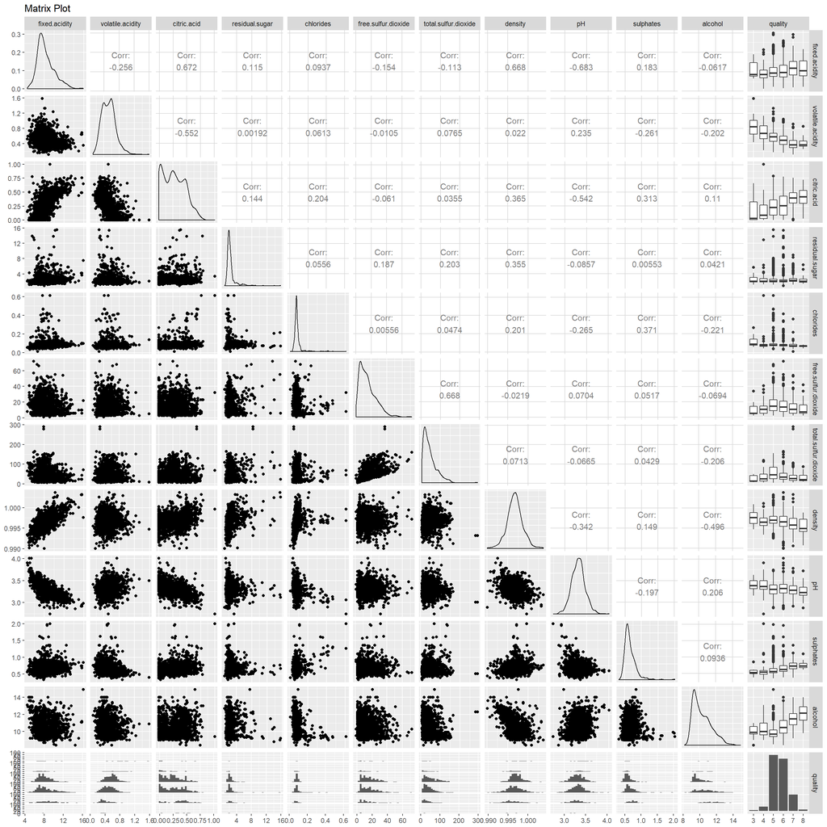

There appear to have significant corelation between a bunch of variables. Let’s explore them further.

**Scatter plot of highly corelated variables**

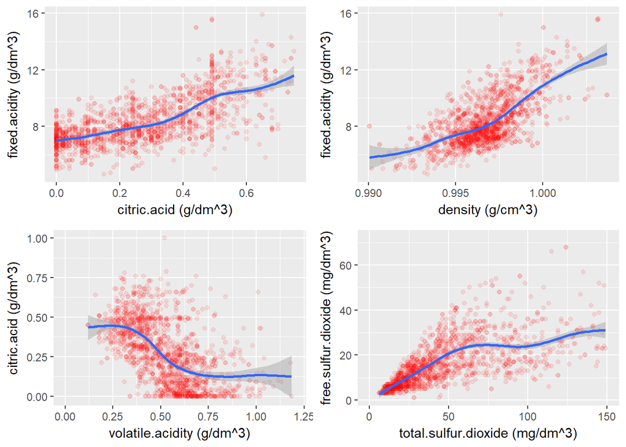

Now, we must closely analyse how does each of the features vary with the quality of wine.

**Relation between features and quality of wine**

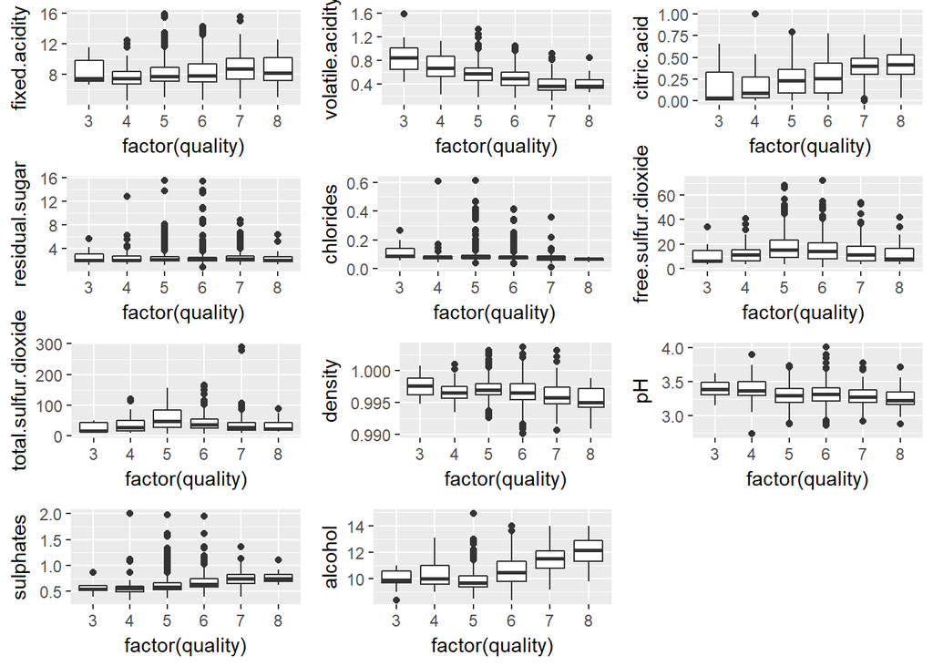

We can confidently say that the quality of wines on an average increases with fixed.acidity, citric.acid sulphates and alcohol.

And the quality of wines decraeses with volatile.acidity density and pH.

Further, residual sugar, chlorides and total.sulfur.dioxide need further investigation.

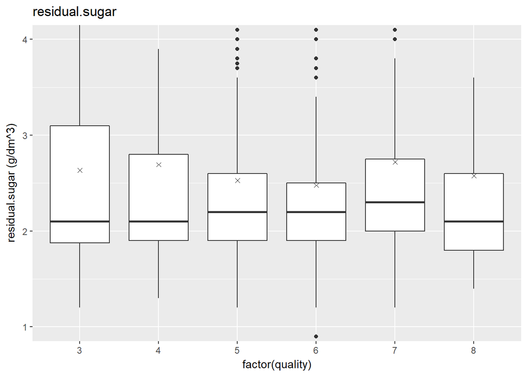

Still, we can’t say anything confidently. Let’s trim some data and observe.

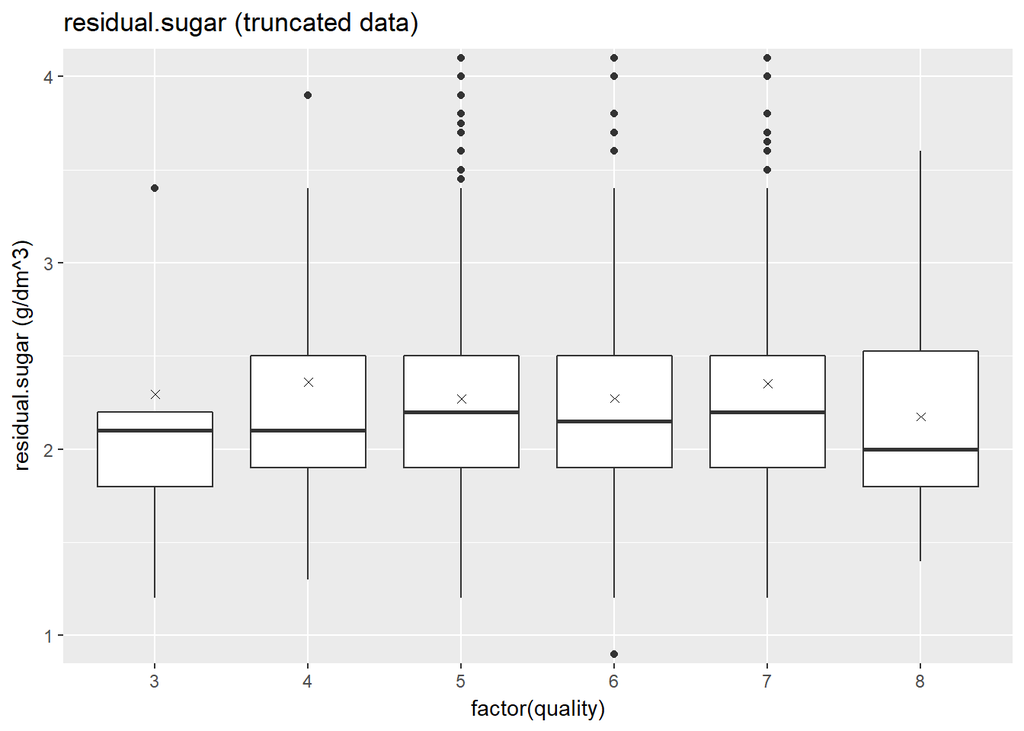

Still we can’t say confidently, how does residual.sugar affects the quality of wine. It appears residual.sugar alone is inconsequential in determining the quality of wines as revealed by the following codes.

```
## df$quality: 3
##    Min. 1st Qu.  Median    Mean 3rd Qu.    Max.
##   1.200   1.875   2.100   2.635   3.100   5.700
## --------------------------------------------------------
## df$quality: 4
##    Min. 1st Qu.  Median    Mean 3rd Qu.    Max.
##   1.300   1.900   2.100   2.694   2.800  12.900
## --------------------------------------------------------
## df$quality: 5
##    Min. 1st Qu.  Median    Mean 3rd Qu.    Max.
##   1.200   1.900   2.200   2.529   2.600  15.500
## --------------------------------------------------------
## df$quality: 6
##    Min. 1st Qu.  Median    Mean 3rd Qu.    Max.
##   0.900   1.900   2.200   2.477   2.500  15.400
## --------------------------------------------------------
## df$quality: 7
##    Min. 1st Qu.  Median    Mean 3rd Qu.    Max.
##   1.200   2.000   2.300   2.721   2.750   8.900
## --------------------------------------------------------
## df$quality: 8
##    Min. 1st Qu.  Median    Mean 3rd Qu.    Max.
##   1.400   1.800   2.100   2.578   2.600   6.400
```

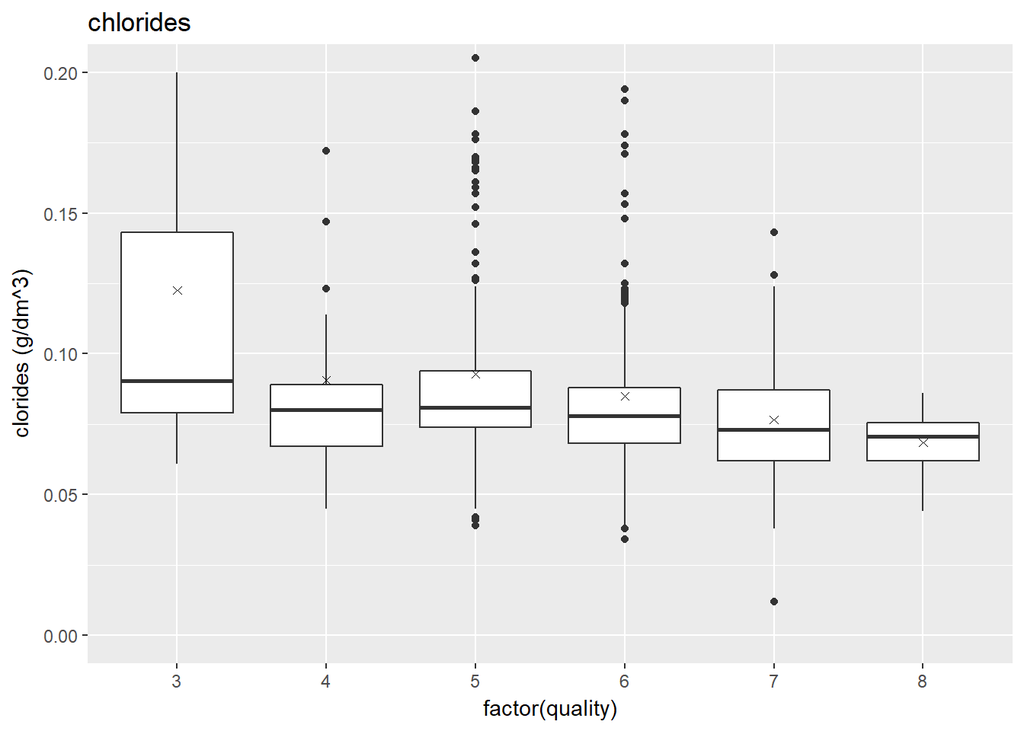

Now, it is crystal clear that as chloride decreases, quality of wines improve on an average.

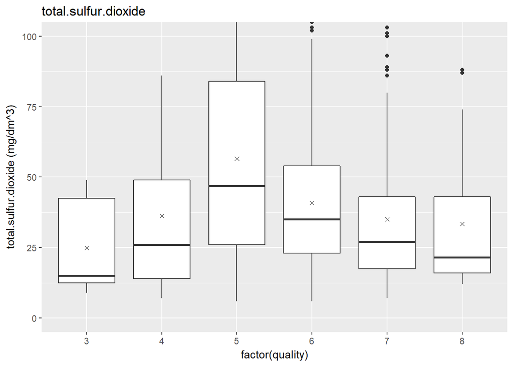

At low total.sulfur.dioxide quality of wine is both very good and very bad, but as it increases to a maximum value, quality of wine averages at the rating 5.

```
## df$quality: 3
##    Min. 1st Qu.  Median    Mean 3rd Qu.    Max.
##     9.0    12.5    15.0    24.9    42.5    49.0
## --------------------------------------------------------
## df$quality: 4
##    Min. 1st Qu.  Median    Mean 3rd Qu.    Max.
##    7.00   14.00   26.00   36.25   49.00  119.00
## --------------------------------------------------------
## df$quality: 5
##    Min. 1st Qu.  Median    Mean 3rd Qu.    Max.
##    6.00   26.00   47.00   56.51   84.00  155.00
## --------------------------------------------------------
## df$quality: 6
##    Min. 1st Qu.  Median    Mean 3rd Qu.    Max.
##    6.00   23.00   35.00   40.87   54.00  165.00
## --------------------------------------------------------
## df$quality: 7
##    Min. 1st Qu.  Median    Mean 3rd Qu.    Max.
##    7.00   17.50   27.00   35.02   43.00  289.00
## --------------------------------------------------------
## df$quality: 8
##    Min. 1st Qu.  Median    Mean 3rd Qu.    Max.
##   12.00   16.00   21.50   33.44   43.00   88.00
```

We can see that with respect to quality, mean total.silfur.dioxide first increases and then decreases.

Let’s explore how variables are distributed and how do they affect quality.

**Matrix plot of historgrams of variables facted by quality(1)**

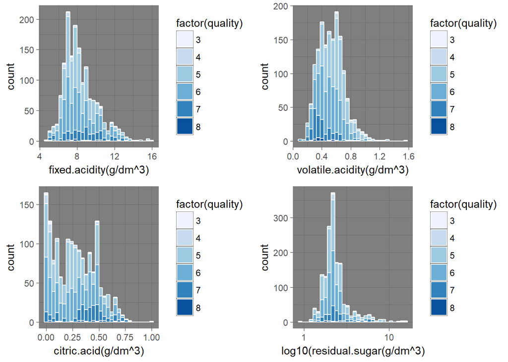

**Matrix plot of historgrams of variables facted by quality(2)**

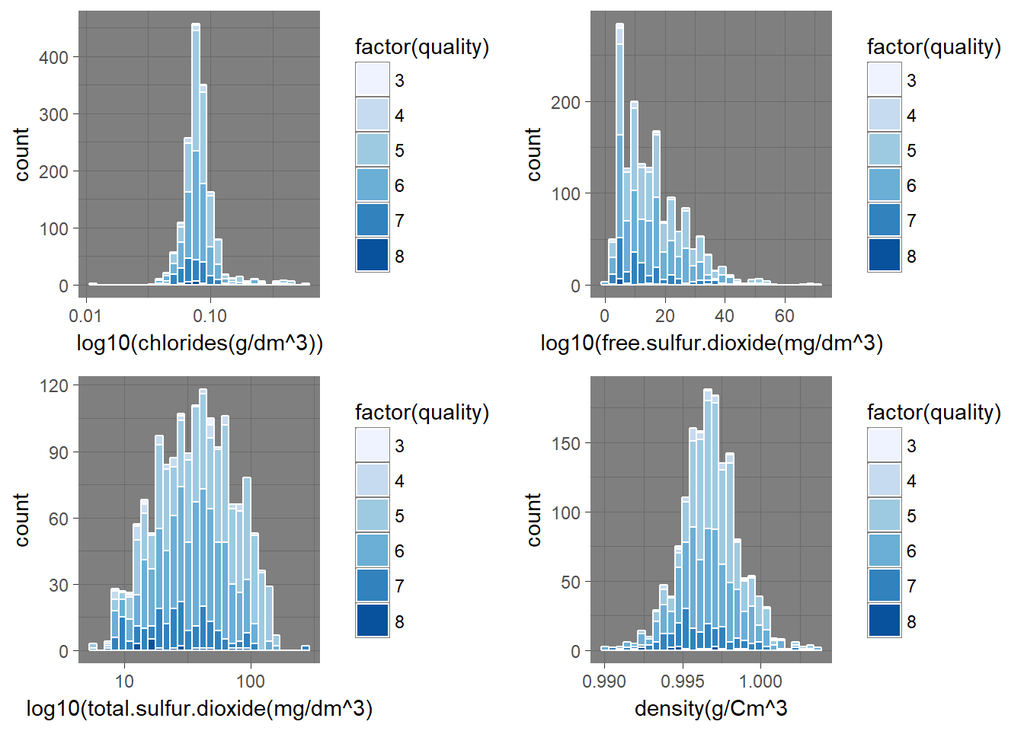

**Matrix plot of historgrams of variables facted by quality(3)**

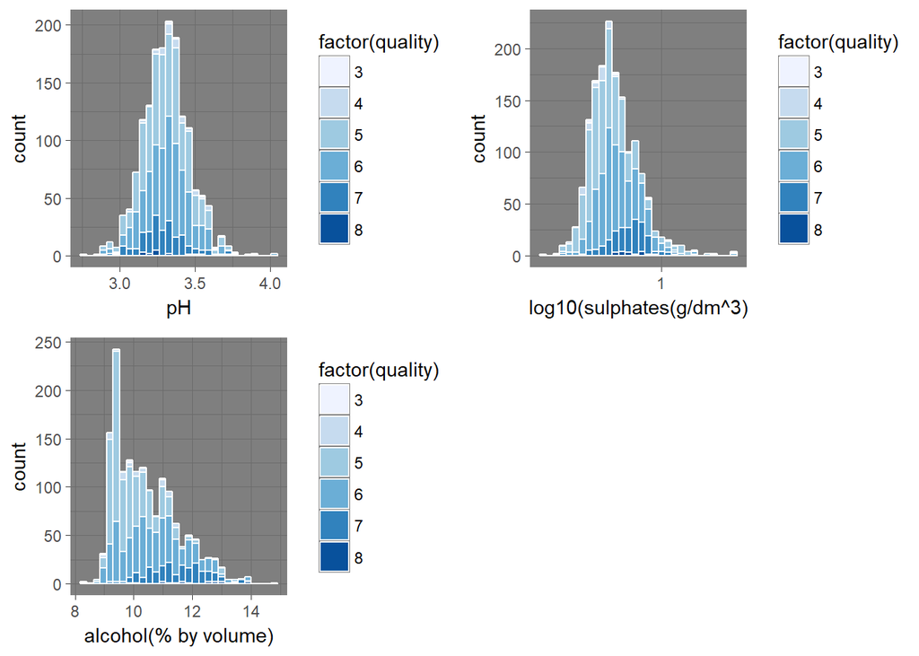

# Bivariate Analysis

We can see there is quite significant co-relation among: citric.acid vs fixed.acidity, density vs fixed.acidity, volatile.acidity vs citric.acid and total.sulfur.dioxide vs free.sulfur dioxide.

We can confidently say that the quality of wines on an average increases with fixed.acidity, citric.acid, sulphates and alcohol.

And the quality of wines decraeses with volatile.acidity density and pH.

On a closer analysis, we conclude that residual sugar is inconsiquential to the quality of wines, rather it is almost constant across the spectrum. While, the quality of wine improves as chlorides content decrease and total.sulfur.dioxide content shows an erratic behavior in influenicng the quality of wines. For example, at low total.sulfur.dioxide quality of wine has been observed to be both very good and very bad.

# Multivariate Plots Section

**Corelation matrix facted by quality**

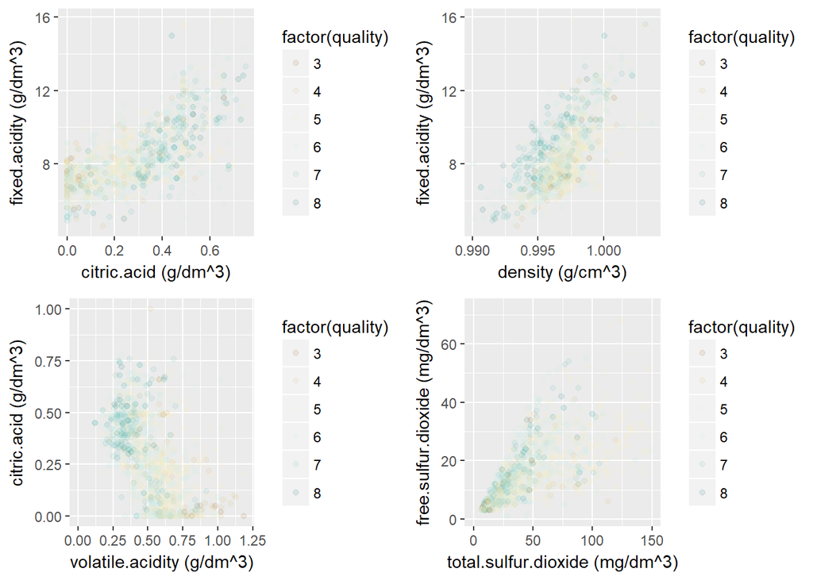

As we can see there are a bunch of variables that have great effect on the quality of wine. We have just one categorical variable over here. Lets try to create a categorical variable citric.acid.factor and observe how does it relate to other variables vis a vis the quality of wines.

```
##
##   high    low medium
##    398    403    798
```

** scatter plot matrix faceted by citric.acid.factor**

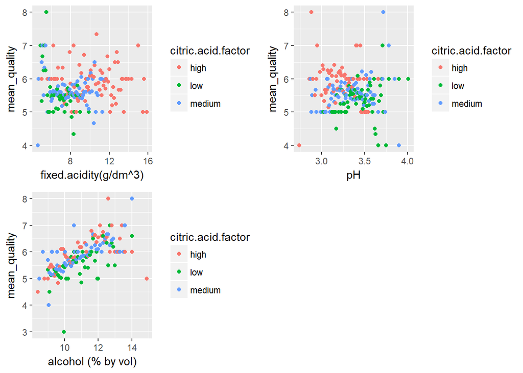

The new factor variable doesn’t offer any meaningful insight into the dataset.

# Multivariate Analysis

For the strongly corelated features, there is a clear discernable chunk of points depicting high quality in each of these plots.

# Final Plots and Summary

### Plot One

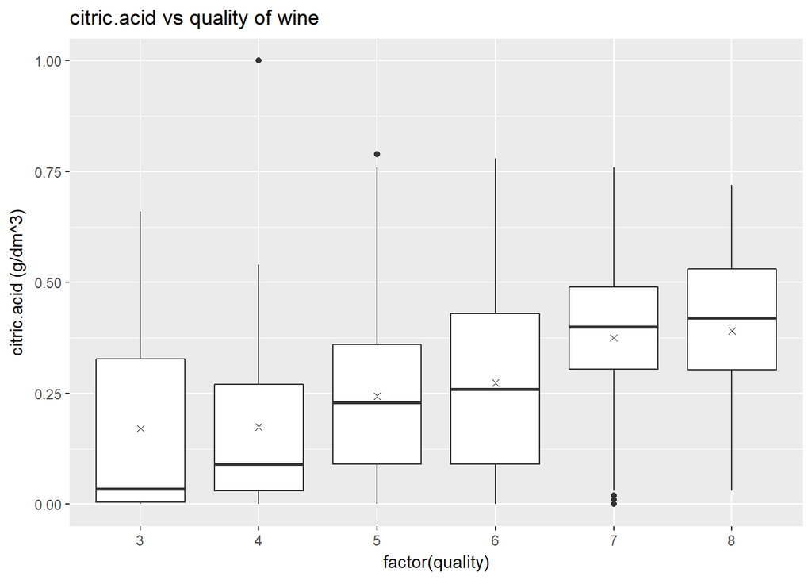

### Description One

This plot beautifully shows the efect of citric.acid on the quality of wine. As the concentration of citric.acid increases, it enhances the quality of wine, this is almost a directly proportional relationship.

### Plot Two

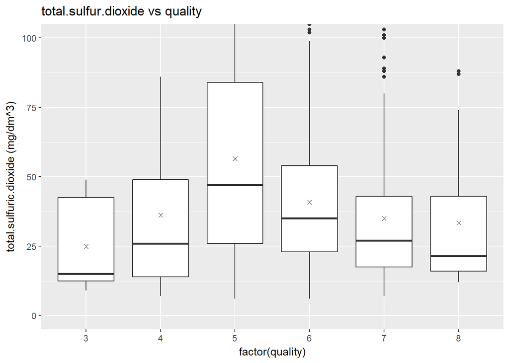

### Description Two

total.sulfur.dioxide presents a very intresting scenario. It is very difficult to determine, how does it affects the quality of wine or is there any effect at all? total.sulfur.dioxide content shows an erratic behavior in influenicng the quality of wines. For example, at low total.sulfur.dioxide concentration quality of wine has been observed to be both very good and very bad.

### Plot Three

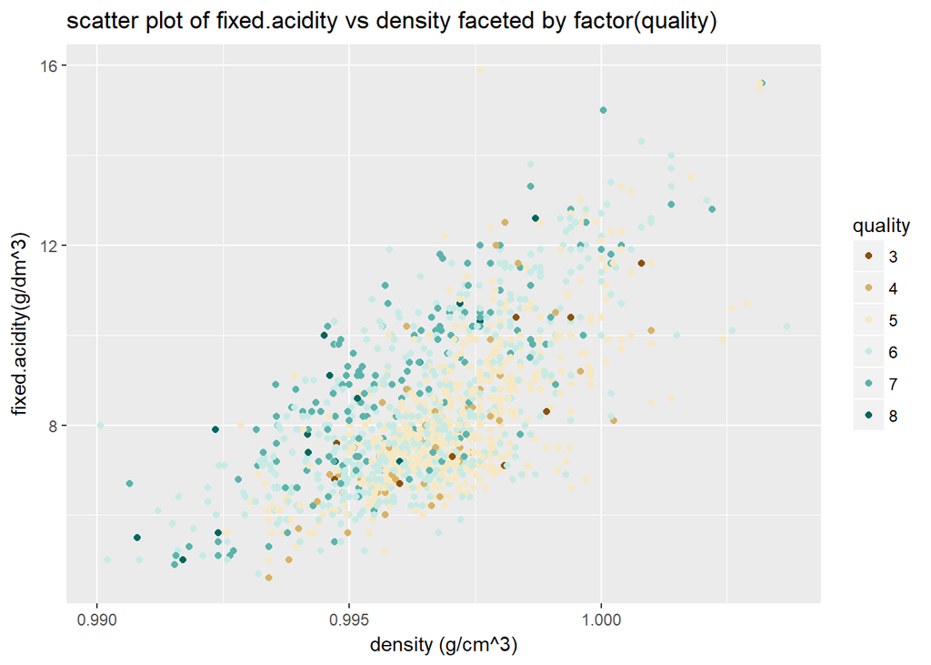

### Description Three

This plot beautifully captures the relationship between most corelated variables and how do they impact the quality. The upper chunk of the cluster of data points have on an average better quality of wine. fixed.acidity in general increases with desnsity, but for a certain density, if the fixed.acidity increases it enhances the quality of the wine.

# Reflection

As this is basically a classification problem. We have only the quality as a categorical variable, I tried creating a few factor variables and create new dataframes using dplyr package and tried to observe how a certain variable contribute to quality, when facted by some categorical variable. But, I could not find any observable pattern or any new information that could help understand the data better. Most likely, because, for variables with a long range, particularly a long tail, just three levels like, ‘low’, ‘medium’ and ‘high’, based on 1st and 3rd quartile, is too broad a categorization compromising the benefit of a new variable. Further, due to lack of the domain knowledge, it is difficult to create a regionable no of levels may 6 or 8 or 15, whatever.